# 24_polar_to_rect

## 24_polar_to_rect

#### Question

1. A point on a Cartesian plane is given in [polar coordinates](https://en.wikipedia.org/wiki/Polar_coordinate_system):
   $$r = 4.76$$
   $$\theta=\frac{10\pi}{13}$$

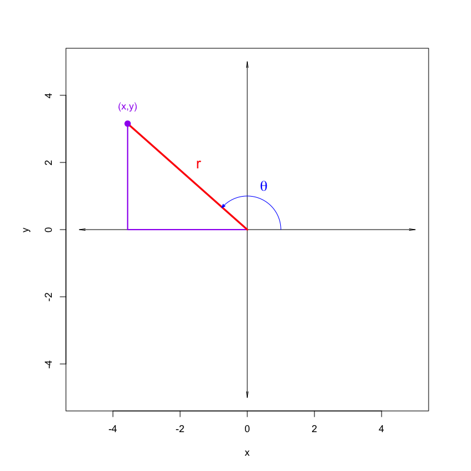

   Please determine the rectangular coordinates ($x$ and $y$).
   - The horizontal coordinate: $x=$
   - The vertical coordinate: $y=$

#### Question

2. A point on a Cartesian plane is given in [polar coordinates](https://en.wikipedia.org/wiki/Polar_coordinate_system):
   $$r = 5.07$$
   $$\theta=\frac{13\pi}{11}$$

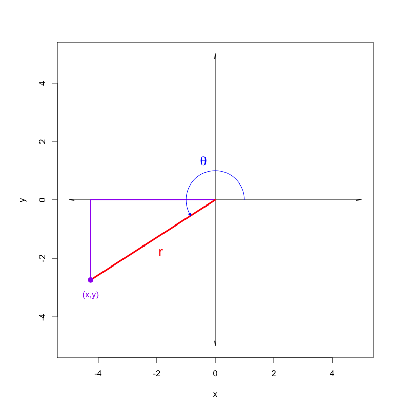

   Please determine the rectangular coordinates ($x$ and $y$).
   - The horizontal coordinate: $x=$
   - The vertical coordinate: $y=$

#### Question

3. A point on a Cartesian plane is given in [polar coordinates](https://en.wikipedia.org/wiki/Polar_coordinate_system):
   $$r = 3.38$$
   $$\theta=\frac{11\pi}{8}$$

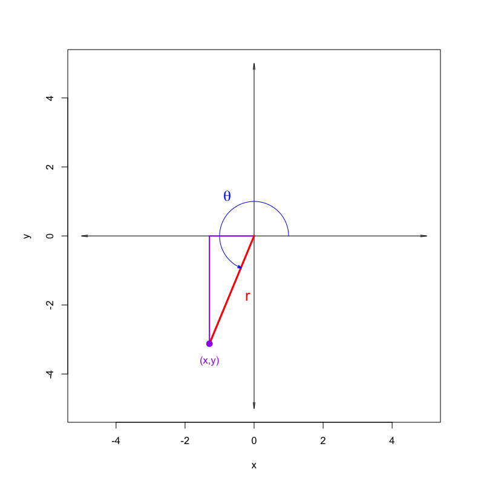

   Please determine the rectangular coordinates ($x$ and $y$).
   - The horizontal coordinate: $x=$
   - The vertical coordinate: $y=$

#### Question

4. A point on a Cartesian plane is given in [polar coordinates](https://en.wikipedia.org/wiki/Polar_coordinate_system):
   $$r = 4.58$$
   $$\theta=\frac{7\pi}{5}$$

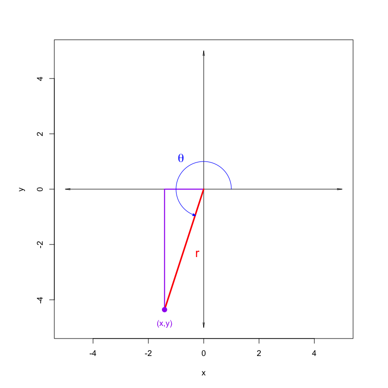

   Please determine the rectangular coordinates ($x$ and $y$).
   - The horizontal coordinate: $x=$
   - The vertical coordinate: $y=$

#### Question

5. A point on a Cartesian plane is given in [polar coordinates](https://en.wikipedia.org/wiki/Polar_coordinate_system):
   $$r = 4.38$$
   $$\theta=\frac{5\pi}{6}$$

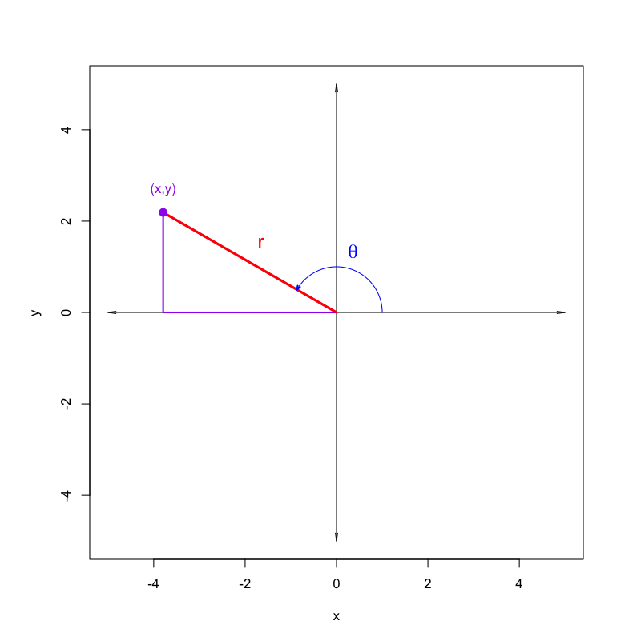

   Please determine the rectangular coordinates ($x$ and $y$).
   - The horizontal coordinate: $x=$
   - The vertical coordinate: $y=$

#### Question

6. A point on a Cartesian plane is given in [polar coordinates](https://en.wikipedia.org/wiki/Polar_coordinate_system):
   $$r = 5.34$$
   $$\theta=\frac{13\pi}{10}$$

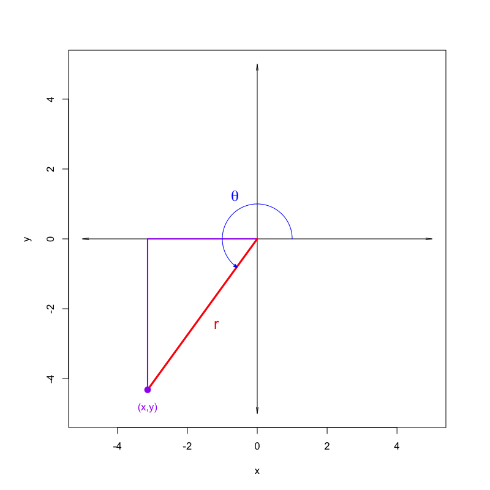

   Please determine the rectangular coordinates ($x$ and $y$).
   - The horizontal coordinate: $x=$
   - The vertical coordinate: $y=$

#### Question

7. A point on a Cartesian plane is given in [polar coordinates](https://en.wikipedia.org/wiki/Polar_coordinate_system):
   $$r = 4.25$$
   $$\theta=\frac{17\pi}{10}$$

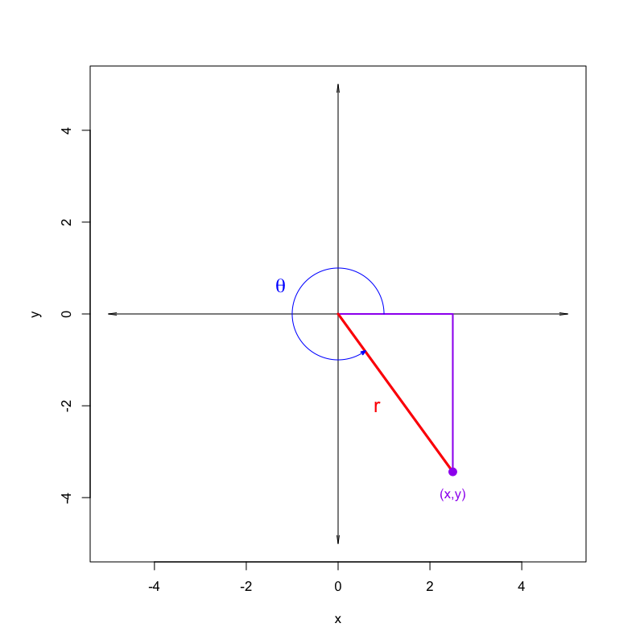

   Please determine the rectangular coordinates ($x$ and $y$).
   - The horizontal coordinate: $x=$
   - The vertical coordinate: $y=$

#### Question

8. A point on a Cartesian plane is given in [polar coordinates](https://en.wikipedia.org/wiki/Polar_coordinate_system):
   $$r = 5.28$$
   $$\theta=\frac{20\pi}{11}$$

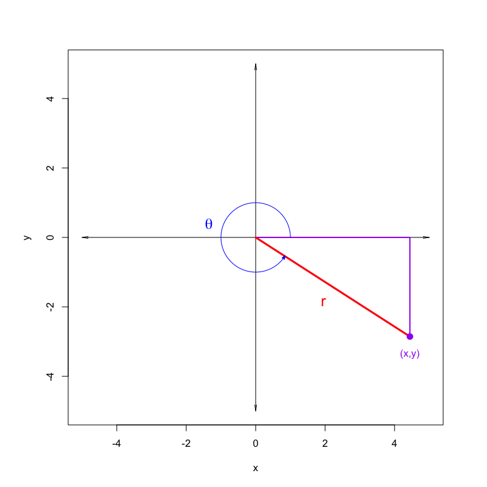

   Please determine the rectangular coordinates ($x$ and $y$).
   - The horizontal coordinate: $x=$
   - The vertical coordinate: $y=$